# Script 2: Étude

Blin - Delalande

2023-11-27

## 1 LES DONNÉES DVF À UNE ÉCHELLE LOCALE : LES EXEMPLES DE LA MÉTROPOLE RÉGIONALE ET DE LA COMMUNE DE Tours

Ce script décrit plusieurs fonctions de manipulation de la dimension spatiale des données DVF. Il propose aussi plusieurs formes de représentation cartographique de ces données à une échelle métropolitaine (Tours Métropole Val de Loire).

## 1.1 Chargement des packages nécessaires

```r
library(tidyverse) # Manipulation de données
library(sf) # Manipulation de données spatiales
```

```r
library(cartography) # Cartographie thématique
library(spdep) # pour calculer l'auto-corrélation spatiale
library(geoR) # pour calculer le semi-variogramme empirique
library(spatstat) # pour produire des surfaces lissées
library(terra) # pour le traitement de données matricielles (raster)
library(cluster) # pour la CAH
```

## 1.2 Import du jeu de données brut

```r
DVF <- read.csv("DVFOK.csv", encoding = "UTF-8")
```

##1.3 Créer le jeu de données correspondant à Tours Métropole Val de Loire (TM) #1.3.1 Extraire les mutations de Tours Métropole Val de Loire

```r
MutationsTM <- DVF %>% filter(EPCI == 'Tours Métropole Val de Loire')
```

#1.3.2 Création d’un tableau avec les indicateurs immobiliers de TM

```r
RecapTM <- MutationsTM %>% group_by(type) %>%
  summarise(tot = n(), prixmed = round(median(prix)), prixmoy = round(mean(prix)), surfmed = round(median(surface)), surfmoy = round(mean(surface)), prixm2med = round(median(prixm2)), prixm2moy = round(mean(prixm2)))
RecapTM <- RecapTM %>% mutate(part = (tot/sum(tot)*100))
print(RecapTM)
```

```
## # A tibble: 2 × 9
##   type          tot prixmed prixmoy surfmed surfmoy prixm2med prixm2moy  part
##   <chr>       <int>   <dbl>   <dbl>   <dbl>   <dbl>     <dbl>     <dbl> <dbl>
## 1 Appartement 19946  110000  125314      56      57      2198      2278  57.6
## 2 Maison      14707  230000  265556      93     103      2471      2640  42.4
```

## 1.4 Exploration des prix et des volumes à l’échelon des Iris

# 1.4.1 Importer la couche des Iris (IGN)

```r
IRISTM <- st_read("IRIS_Tours.gpkg")
```

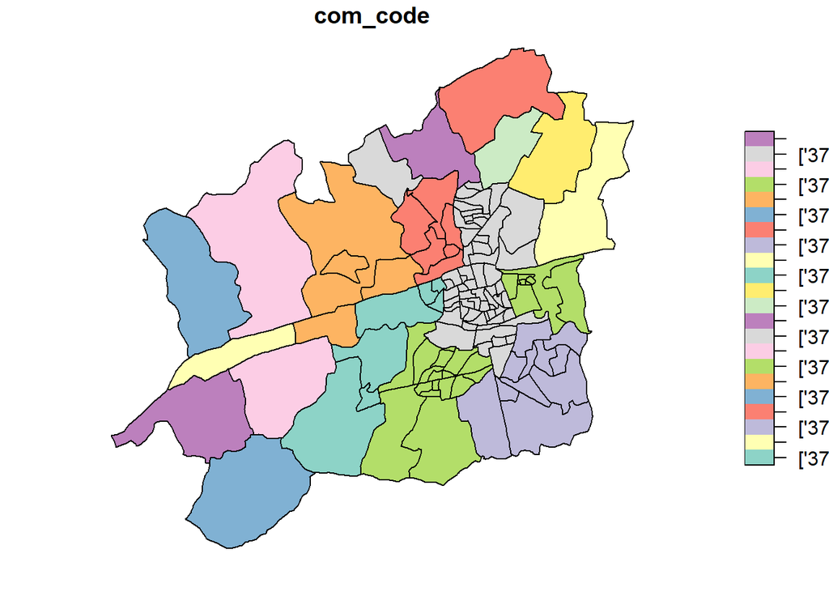

```r
IRISTM <- IRISTM[!duplicated(IRISTM), ]
plot(IRISTM["com_code"])
```

# 1.4.2 Calculer et cartographier le prix moyen au m² par Iris

```r
# Réimporter si nécessaire la couche des communes de la métropole dans le script
Communes <- st_read("CommunesTM.gpkg")
MutationsTM <- st_as_sf(MutationsTM, coords = c("longitude", "latitude"), crs = 4326)
class(MutationsTM)
```

```
## [1] "sf"         "data.frame"
```

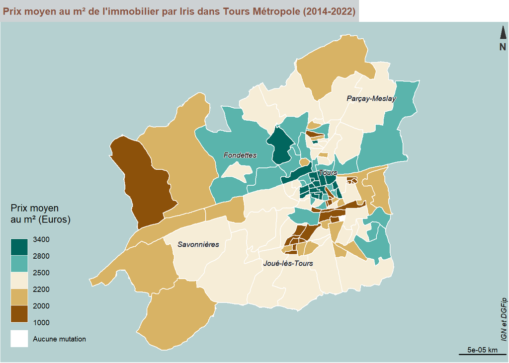

```r
# Calcul du prix moyen au m² par IRIS
IRISDVF <- IRISTM %>% st_join(MutationsTM) %>% group_by(iris_code) %>% summarise(prixm2 = round(mean(prixm2)))

# Sélection des communes dont le nom sera affiché sur la carte
liste_noms_TM <- c("Tours", "Joué-lès-Tours", "Savonnières", "Fondettes", "Parçay-Meslay")
Selection_Communes_TM <- Communes[which(Communes$commune %in% liste_noms_TM),]

# Paramétrage des marges de la fenêtre pour maximiser l'emprise de la carte
par(mar = c(0, 0, 1.5, 0))

# Affichage des communes de RM et alentours en arrière-plan et centrage de la carte sur Tours Métropole
plot(st_geometry(Communes), lwd = 0.1, col = "grey95", border = "white", bg = "#B5D0D0", xlim = c(st_bbox(IRISTM)[1], st_bbox(IRISTM)[3]), ylim = c(st_bbox(IRISTM)[2], st_bbox(IRISTM)[4]))


choroLayer(
  x = IRISDVF,
  var = "prixm2",
  breaks = c(1000, 2000, 2200, 2500, 2800, 3400),
  col = c("#8c510a", "#d8b365", "#f6edd7", "#5ab4ac", "#01665e"),
  add = TRUE,
  border = "white",
  legend.nodata = "Aucune mutation",
  legend.border = "white",
  legend.title.txt = "Prix moyen \nau m² (Euros)")

layoutLayer(title = "Prix moyen au m² de l'immobilier par Iris dans Tours Métropole (2014-2022)", source = "         IGN et DGFip",
            north = TRUE, horiz = FALSE, tabtitle = TRUE,
            frame = FALSE, col = "#cdd2d4", coltitle = "#8A5543")

# Ajouter les étiquettes des communes selectionnées plus haut
labelLayer(Selection_Communes_TM, txt = "commune", halo = TRUE, bg = "grey90", r = 0.05, cex = 0.6, pos = 3, font = 3, offset = 0, overlap = TRUE)
```

# 1.4.3 Calculer et cartographier le nombre de mutations par Iris

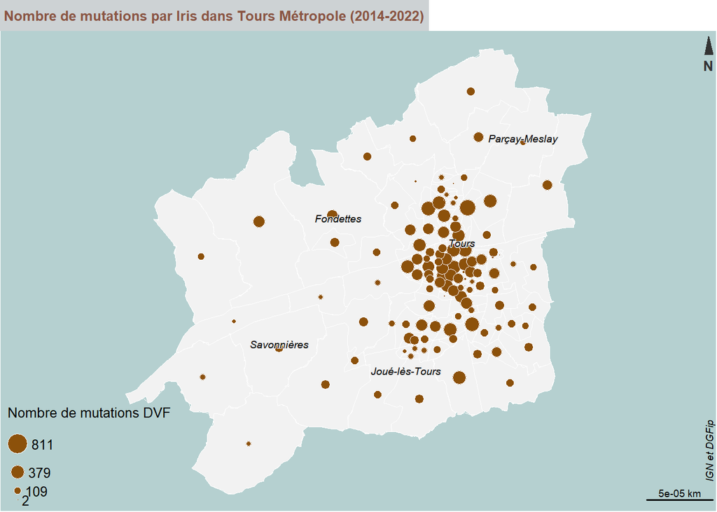

```r
# Calcul du nombre de mutations par IRIS
IRISDVF <- IRISDVF %>% mutate(Nbmutations = lengths(st_intersects(IRISDVF, MutationsTM)))
IRISDVF <- IRISDVF %>% na.omit() # pour supprimer les valeurs manquantes

# Paramétrage des marges de la fenêtre pour maximiser l'emprise de la carte
par(mar = c(0, 0, 1.5, 0))

# Affichage des communes de RM et alentours en arrière-plan et centrage de la carte sur Tours Métropole
plot(st_geometry(Communes), lwd = 0.1, col = "grey95", border = "white", bg = "#B5D0D0", xlim = c(st_bbox(IRISTM)[1], st_bbox(IRISTM)[3]), ylim = c(st_bbox(IRISTM)[2], st_bbox(IRISTM)[4]))

# Affichage des IRIS
plot(st_geometry(IRISTM), # appel du jeu de données
     border = "white", # couleur de la bordure des IRIS
     add = TRUE,
     lwd = 0.05)

# Affichage des symboles proportionnels (nombre de mutations)
propSymbolsLayer(x = IRISDVF, # appel du jeu de données
                 var = "Nbmutations", # appel de la variable à cartographier
                 col = "#8c510a", # couleur des cercles
                 border = "white",  # couleur du contour des cercles
                 lwd = 0.01,
                 inches = 0.08, # Taille des cercles
                 add = TRUE,
                 legend.pos = "n",
                 )

layoutLayer(title = "Nombre de mutations par Iris dans Tours Métropole (2014-2022)", source = "         IGN et DGFip", north = TRUE, horiz = FALSE, tabtitle = TRUE, frame = FALSE, col = "#cdd2d4", coltitle = "#8A5543")

legendCirclesSymbols(
  pos = "bottomleft",
  title.txt = "Nombre de mutations DVF",
  title.cex = 0.8,
  cex = 0.5,
  border = "white",
  lwd = 0.01,
  values.cex = 0.8,
  var = c(min(IRISDVF$Nbmutations), max(IRISDVF$Nbmutations)),
  inches = 0.1,
  col = "#8c510a",
  frame = FALSE,
  values.rnd = 0,
  style = "e"
)

# Ajouter les étiquettes des communes selectionnées plus haut
labelLayer(Selection_Communes_TM, txt = "commune", halo = TRUE, bg = "grey90", r = 0.05, cex = 0.6, pos = 3, font = 3, offset = 0, overlap = TRUE)
```

## 1.5 Exploration des prix et des volumes à l’échelon des sections cadastrales

# 1.5.1 Importer la couche des sections cadastrales (DGFip)

```r
Sections <- st_read("Cadastre_Tours.gpkg")
```

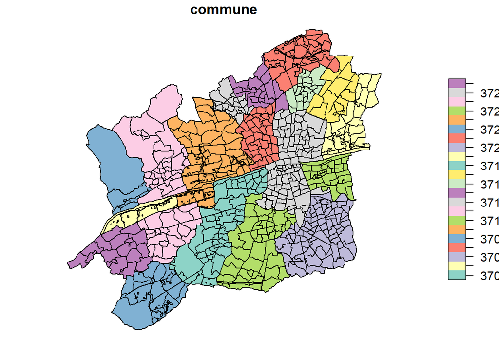

```r
Sections <- Sections %>% mutate(codesection = id)
plot(Sections["commune"])
```

# 1.5.2 Calculer et cartographier le prix moyen au m² par section cadastrale

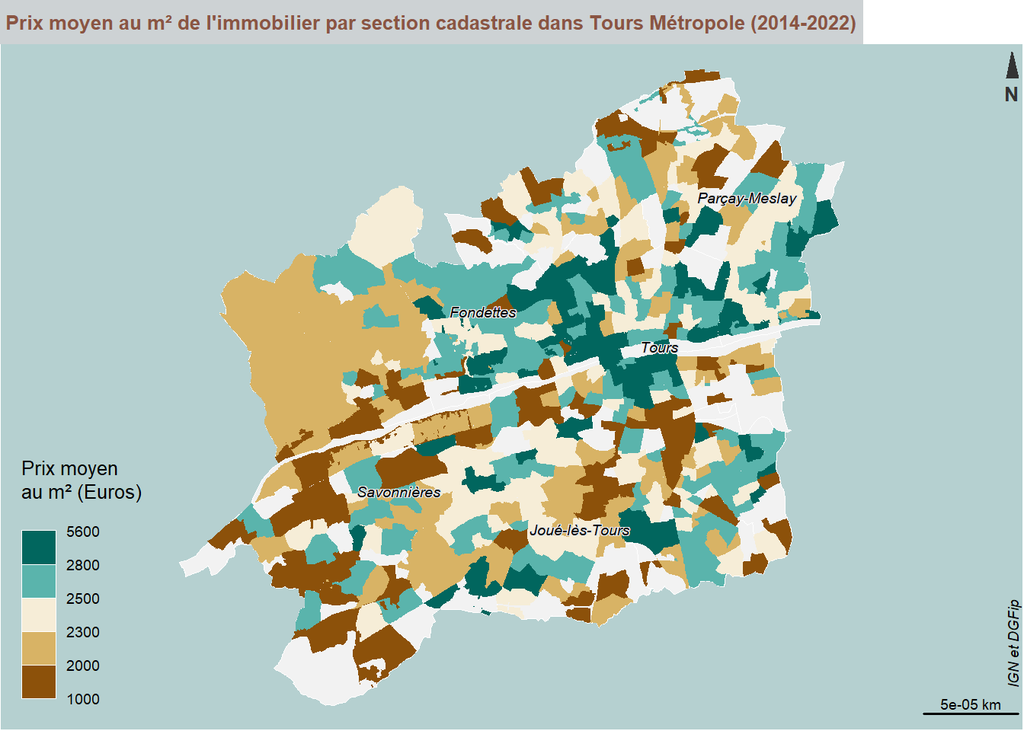

```r
# Calcul du prix moyen au m² par section
SectionsDVF <- Sections %>% st_join(MutationsTM) %>% group_by(codesection) %>% summarise(prixm2 = round(mean(prixm2)))
SectionsDVF <- SectionsDVF %>% na.omit() # pour supprimer les valeurs manquantes

# Paramétrage des marges de la fenêtre pour maximiser l'emprise de la carte
par(mar = c(0, 0, 1.5, 0))

# Affichage des communes de RM et alentours en arrière-plan et centrage de la carte sur Tours Métropole
plot(st_geometry(Communes), lwd = 0.1, col = "grey95", border = "white", bg = "#B5D0D0", xlim = c(st_bbox(IRISTM)[1], st_bbox(IRISTM)[3]), ylim = c(st_bbox(IRISTM)[2], st_bbox(IRISTM)[4]))

# Affichage de la carte des prix au m² par section cadastrale
choroLayer(
  x = SectionsDVF,
  var = "prixm2",
  breaks =  c(1000, 2000, 2300, 2500, 2800, 5600),
  col = c("#8c510a", "#d8b365", "#f6edd7", "#5ab4ac", "#01665e"),
  add = TRUE,
  border = NA,
  legend.nodata = "Aucune mutation",
  legend.border = "white",
  legend.title.txt = "Prix moyen \nau m² (Euros)")

layoutLayer(title = "Prix moyen au m² de l'immobilier par section cadastrale dans Tours Métropole (2014-2022)", source = "         IGN et DGFip",
            north = TRUE, horiz = FALSE, tabtitle = TRUE,
            frame = FALSE, col = "#cdd2d4", coltitle = "#8A5543")

# Ajouter les étiquettes des communes selectionnées plus haut
labelLayer(Selection_Communes_TM, txt = "commune", halo = TRUE, bg = "grey90", r = 0.05, cex = 0.6, pos = 3, font = 3, offset = 0, overlap = TRUE)
```

#1.5.3 Calculer et cartographier le nombre de mutations par section cadastrale

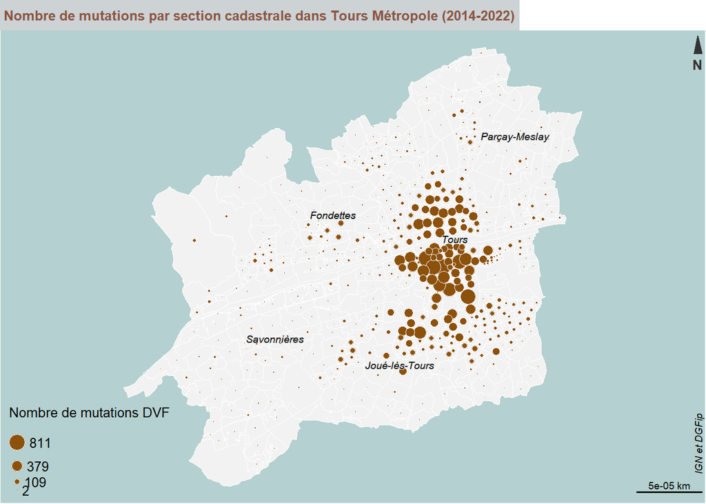

```r
# Calcul du nombre de mutations par section
SectionsDVF <- SectionsDVF %>% mutate(Nbmutations = lengths(st_intersects(SectionsDVF, MutationsTM)))

# Paramétrage des marges de la fenêtre pour maximiser l'emprise de la carte
par(mar = c(0, 0, 1.5, 0))

# Affichage des communes de RM et alentours en arrière-plan et centrage de la carte sur Tours Métropole
plot(st_geometry(Communes), lwd = 0.1, col = "grey95", border = "white", bg = "#B5D0D0", xlim = c(st_bbox(IRISTM)[1], st_bbox(IRISTM)[3]), ylim = c(st_bbox(IRISTM)[2], st_bbox(IRISTM)[4]))

# Affichage des sections cadastrales
plot(st_geometry(SectionsDVF), # appel du jeu de données
     border = "white", # couleur de la bordure
     add = TRUE,
     lwd = 0.05)

# Affichage des symboles proportionnels (nombre de mutations)
propSymbolsLayer(x = SectionsDVF, # appel du jeu de données
                 var = "Nbmutations", # appel de la variable à cartographier
                 col = "#8c510a", # couleur cercles
                 border = "white",  # couleur du contour des cercles
                 lwd = 0.01,
                 inches = 0.08, # Taille des cercles
                 add = TRUE,
                 legend.pos = "n",
                 )

layoutLayer(title = "Nombre de mutations par section cadastrale dans Tours Métropole (2014-2022)", source = "         IGN et DGFip", north = TRUE, horiz = FALSE, tabtitle = TRUE, frame = FALSE, col = "#cdd2d4", coltitle = "#8A5543")

legendCirclesSymbols(
  pos = "bottomleft",
  title.txt = "Nombre de mutations DVF",
  title.cex = 0.8,
  cex = 0.6,
  border = "white",
  lwd = 0.01,
  values.cex = 0.8,
  var = c(min(IRISDVF$Nbmutations), max(IRISDVF$Nbmutations)),
  inches = 0.08,
  col = "#8c510a",
  frame = FALSE,
  values.rnd = 0,
  style = "e"
)

# Ajouter les étiquettes des communes selectionnées plus haut
labelLayer(Selection_Communes_TM, txt = "commune", halo = TRUE, bg = "grey90", r = 0.05, cex = 0.6, pos = 3, font = 3, offset = 0, overlap = TRUE)
```

# 1.6 Lissage spatial (échelle métropolitaine)

## 1.6.1 Lissage spatial des prix de l’immobilier au m² calculés à partir des valeurs agrégées par Iris

### 1.6.1.1 Calcul des distances au plus proche voisin et de l’auto-corrélation spatiale des prix au m²

```r
# pour calculer les pseudo-centroides des Iris (indispensable pour le calcul sur les plus proches voisins)
IRISDVF.Centroids <- st_point_on_surface(IRISDVF)
# Identification du plus proche voisin de chaque Iris
listPPV <- knearneigh(IRISDVF.Centroids, k = 1) # pour connaître le plus proche voisin de chaque Iris
PPV <- knn2nb(listPPV, row.names = IRISDVF.Centroids$code_iris) # pour convertir l'objet knn en objet nb
distPPV <- nbdists(PPV, IRISDVF.Centroids) # pour connaître la distance entre plus proches voisins
print(as.data.frame(t(as.matrix(summary(unlist(distPPV))))))
```

```
##        Min.  1st Qu.    Median      Mean  3rd Qu.    Max.
## 1 0.1635777 0.423988 0.6259815 0.9936655 1.203204 4.97571
```

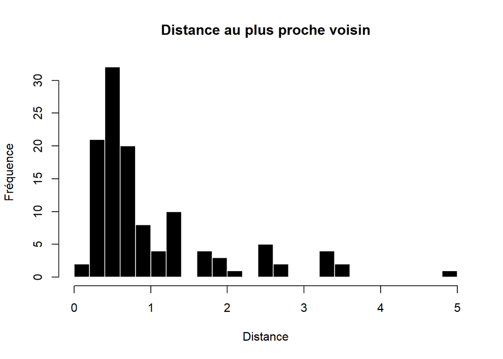

```r
hist(unlist(distPPV), breaks = 20,
     main = "Distance au plus proche voisin",
     col = "black", border = "white", xlab = "Distance", ylab = "Fréquence")
```

```r
# pour convertir les Iris en objet nb
IRIS.nb <- poly2nb(pl = IRISDVF,
                 snap = 50,
                 queen = TRUE)

#calcul du test de Moran
moran.test(IRISDVF$prixm2, listw = nb2listw(IRIS.nb))
```

```
##
##  Moran I test under randomisation
##
## data:  IRISDVF$prixm2
## weights: nb2listw(IRIS.nb)
##
## Moran I statistic standard deviate = 8.9735, p-value < 2.2e-16
## alternative hypothesis: greater
## sample estimates:
## Moran I statistic       Expectation          Variance
##       0.483692872      -0.008474576       0.003008150
```

### 1.6.1.2 Carte lissée des prix de l’immobilier au m² calculés à partir des valeurs agrégées par Iris sur l’ensemble de Tours Métropole

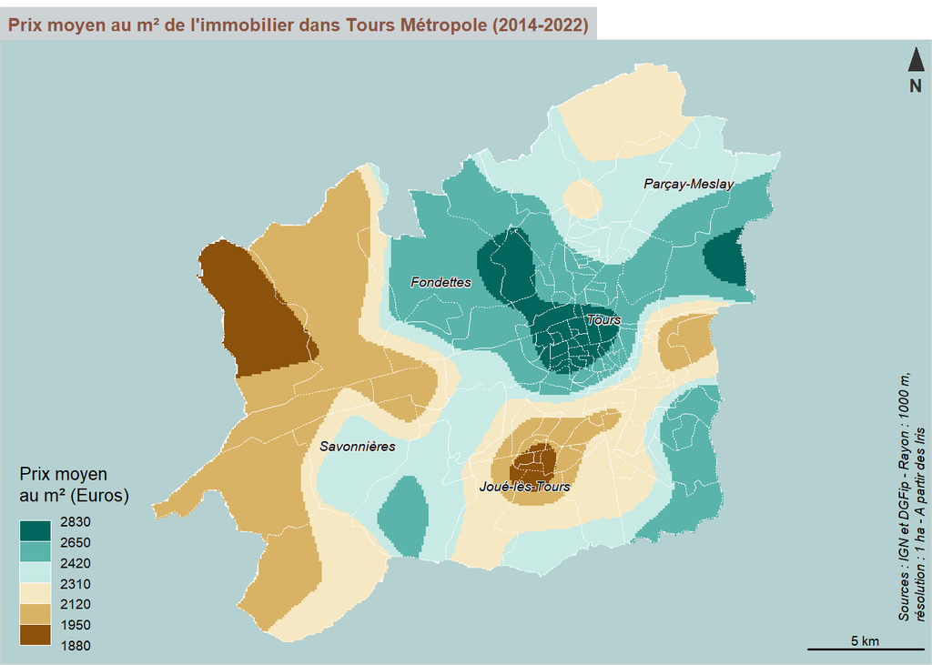

```r
#Reprojection de nos différentes données, car nous avions un problème lors du lancement des requetes suivantes.
IRISTM <- st_transform(IRISTM, crs = 2154)
DVF <- st_as_sf(DVF, coords = c("longitude", "latitude"), crs = 4326)
DVF <- st_transform(DVF, crs = 2154)
IRISDVF <- st_transform(IRISDVF, crs = 2154)
IRISDVF.Centroids <- st_transform(IRISDVF.Centroids, crs = 2154)
MutationsTM <- st_transform(MutationsTM, crs = 2154)
SectionsDVF <- st_transform(SectionsDVF, crs = 2154)
Selection_Communes_TM <- st_transform(Selection_Communes_TM, crs = 2154)
Communes <- st_transform(Communes, crs = 2154)

# pour définir le contour de Tours Métropole comme emprise pour le lissage (sinon le lissage est calculé sur une fenêtre rectangulaire)
EmpriseTM <- as.owin(st_geometry(IRISTM))

# pour récupérer les coordonnées du centroïde des IRIS
pts <- st_coordinates(st_point_on_surface(st_geometry(IRISDVF)))

# pour créer un objet ppp (format spatstat) et y intégrer dedans l'emprise et les valeurs à lisser (prix au m²)
IRISDVF.ppp <- ppp(pts[,1], pts[,2], window = EmpriseTM, marks = IRISDVF$prixm2)

# pour calculer la surface lissée (rayon lissage : 1 km et resolution spatiale de l'image : 1 ha)
cartelissee <- Smooth(IRISDVF.ppp, sigma = 1000, weights = IRISDVF.ppp$marks, eps = 100)

# Conversion de la surface lissée au format raster
cartelissee.raster <- terra::rast(cartelissee)
crs(cartelissee.raster) <- st_crs(Communes)$srid

# Paramétrage des marges de la fenêtre pour maximiser l'emprise de la carte
par(mar = c(0, 0, 1.5, 0))

# pour afficher la surface lissée et définir l'habillage
# Calcul des seuils
bks <- unique(getBreaks(values(cartelissee.raster), method = "q6"))

# Création d'une palette de couleurs (double gradation harmonique)
cols <- c("#8c510a", "#d8b365", "#f6e8c3", "#c7eae5", "#5ab4ac", "#01665e")

# Affichage des communes de RM et alentours en arrière-plan et centrage de la carte sur Tours Métropole
plot(st_geometry(Communes), lwd = 0.1, col = "grey95", border = "white", bg = "#B5D0D0", xlim = c(st_bbox(IRISTM)[1], st_bbox(IRISTM)[3]), ylim = c(st_bbox(IRISTM)[2], st_bbox(IRISTM)[4]))

# Affichage de la carte lissée et du contour des Iris
plot(cartelissee.raster, breaks = bks, col = cols, add = T, legend = F)
plot(IRISDVF$geom, border = "white", lwd = 0.05, lty = 3, add = T)

legendChoro(
  pos = "bottomleft",
  title.txt = "Prix moyen \nau m² (Euros)",
  breaks = bks,
  nodata = F,
  values.rnd = -1,
  border = "white",
  col = cols
)

# Habillage de la carte
layoutLayer(title = "Prix moyen au m² de l'immobilier dans Tours Métropole (2014-2022)",
            author = "          Sources : IGN et DGFip - Rayon : 1000 m,\n          résolution : 1 ha - A partir des Iris",
            scale = 5, frame = TRUE, col = "#cdd2d4", coltitle = "#8A5543",
            north = TRUE, tabtitle = TRUE, horiz = FALSE)

# Ajouter les étiquettes des communes sélectionnées plus haut
labelLayer(Selection_Communes_TM, txt = "commune", halo = TRUE, bg = "grey90", r = 0.05, cex = 0.6, pos = 3, font = 3, offset = 0)
```